# Analysis of the Properties Influencing the Quality of Red Wine

Grayson Ricketts

March 21, 2016

### Guiding question:

Which chemical properties influence the quality of red wines?

### Basic data exploration and Summary

```
## [1] 1599   13
```

```
##  [1] "X"                    "fixed.acidity"        "volatile.acidity"
##  [4] "citric.acid"          "residual.sugar"       "chlorides"
##  [7] "free.sulfur.dioxide"  "total.sulfur.dioxide" "density"
## [10] "pH"                   "sulphates"            "alcohol"
## [13] "quality"
```

```
## 'data.frame':    1599 obs. of  13 variables:
##  $ X                   : int  1 2 3 4 5 6 7 8 9 10 ...
##  $ fixed.acidity       : num  7.4 7.8 7.8 11.2 7.4 7.4 7.9 7.3 7.8 7.5 ...
##  $ volatile.acidity    : num  0.7 0.88 0.76 0.28 0.7 0.66 0.6 0.65 0.58 0.5 ...
##  $ citric.acid         : num  0 0 0.04 0.56 0 0 0.06 0 0.02 0.36 ...
##  $ residual.sugar      : num  1.9 2.6 2.3 1.9 1.9 1.8 1.6 1.2 2 6.1 ...
##  $ chlorides           : num  0.076 0.098 0.092 0.075 0.076 0.075 0.069 0.065 0.073 0.071 ...
##  $ free.sulfur.dioxide : num  11 25 15 17 11 13 15 15 9 17 ...
##  $ total.sulfur.dioxide: num  34 67 54 60 34 40 59 21 18 102 ...
##  $ density             : num  0.998 0.997 0.997 0.998 0.998 ...
##  $ pH                  : num  3.51 3.2 3.26 3.16 3.51 3.51 3.3 3.39 3.36 3.35 ...
##  $ sulphates           : num  0.56 0.68 0.65 0.58 0.56 0.56 0.46 0.47 0.57 0.8 ...
##  $ alcohol             : num  9.4 9.8 9.8 9.8 9.4 9.4 9.4 10 9.5 10.5 ...
##  $ quality             : int  5 5 5 6 5 5 5 7 7 5 ...
```

[data set description](https://s3.amazonaws.com/udacity-hosted-downloads/ud651/wineQualityInfo.txt)

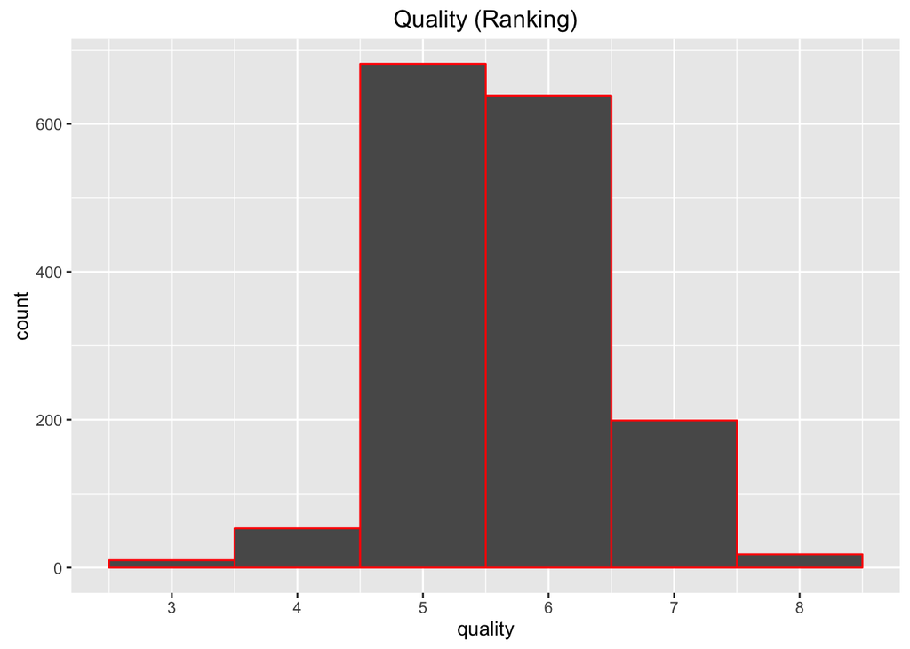

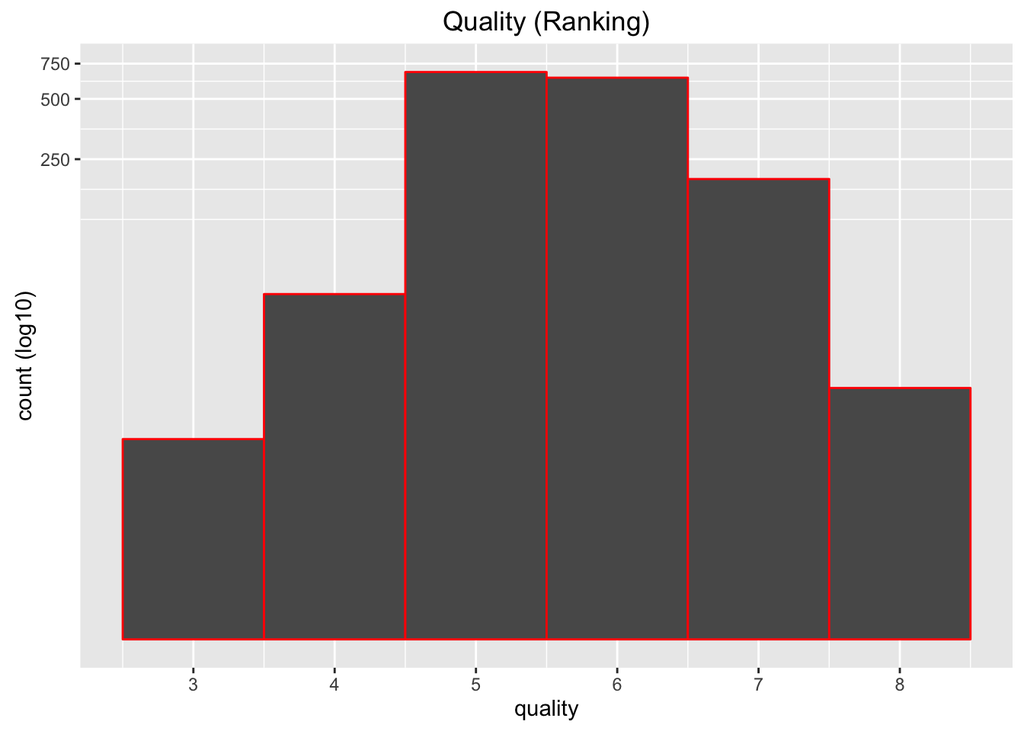

```
##
##   3   4   5   6   7   8
##  10  53 681 638 199  18
```

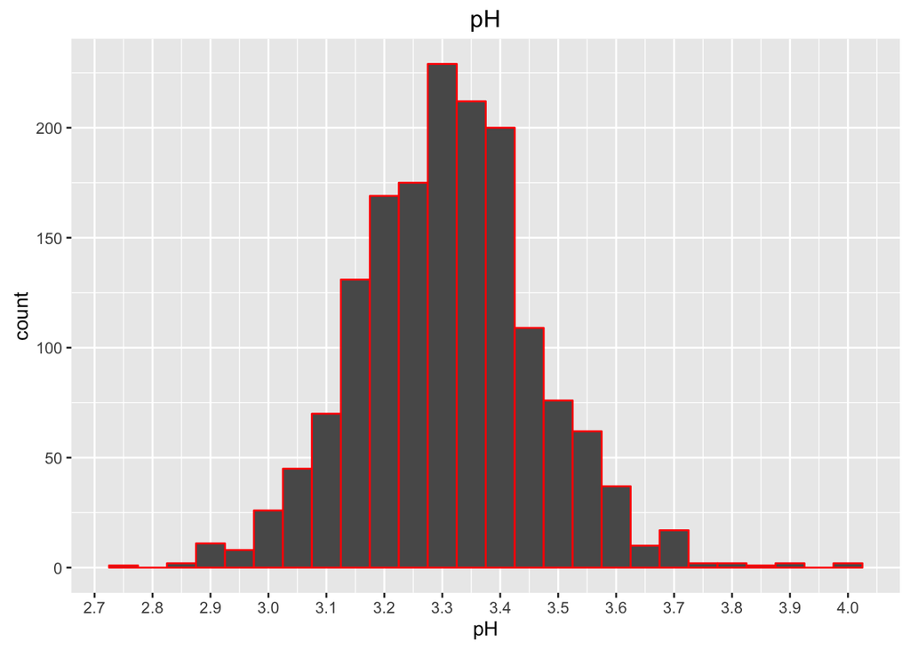

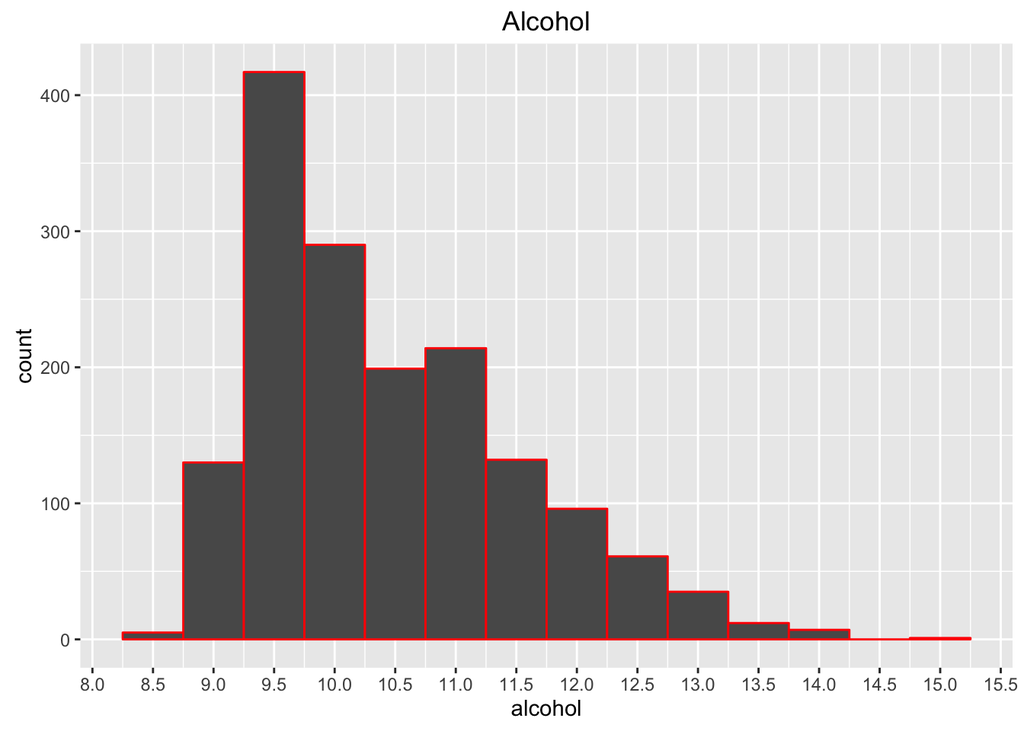

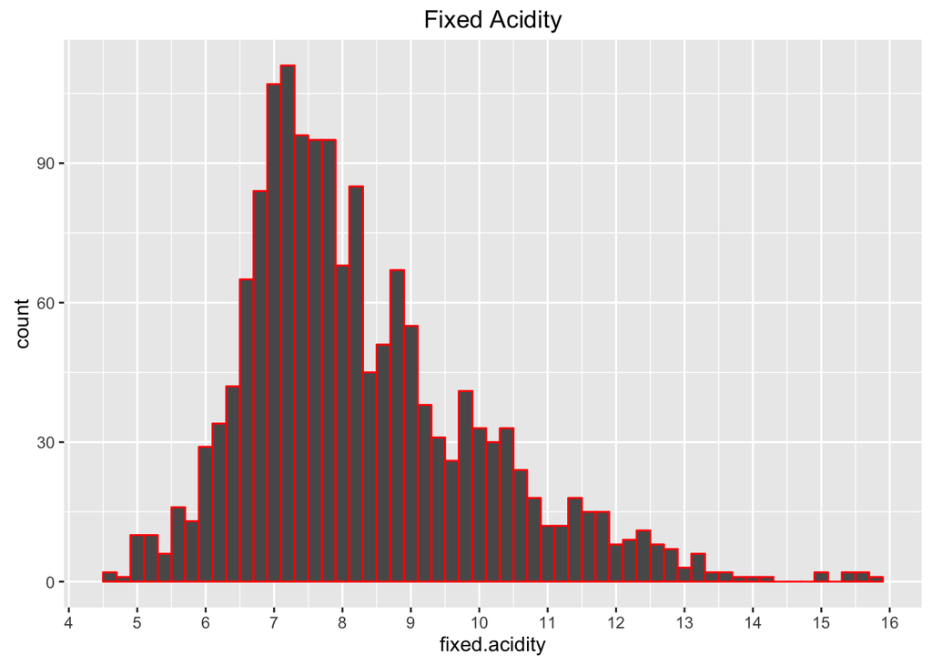

Overall acidity, alcohol level, and the fixed acidity all are normally distributed with positive skewness on acohol and fixed acidity.

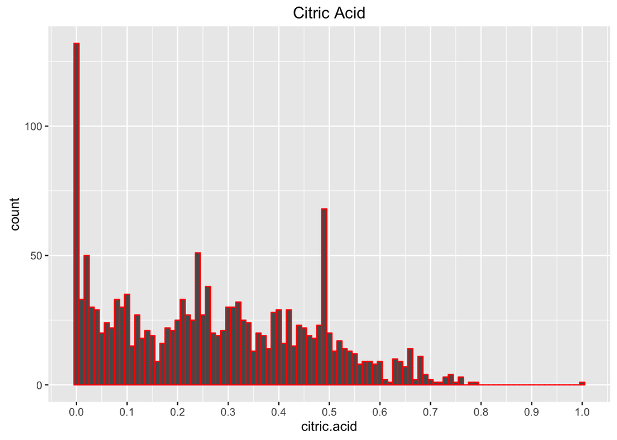

Citric acid in a large number of wines is 0, and the distribution is positively–and noticeable flat– skewed.

#### Acid summaries (Fixed, volatile, citric)

```
##    Min. 1st Qu.  Median    Mean 3rd Qu.    Max.
##    4.60    7.10    7.90    8.32    9.20   15.90
```

```
##    Min. 1st Qu.  Median    Mean 3rd Qu.    Max.
##  0.1200  0.3900  0.5200  0.5278  0.6400  1.5800
```

```
##    Min. 1st Qu.  Median    Mean 3rd Qu.    Max.
##   0.000   0.090   0.260   0.271   0.420   1.000
```

Each acidity measurement seems to be different. Fixed acidity seems to be positively skewed while volatile acidity is less harshly skewed but has some positive outliers while citric acid has a almost exponential distribution.

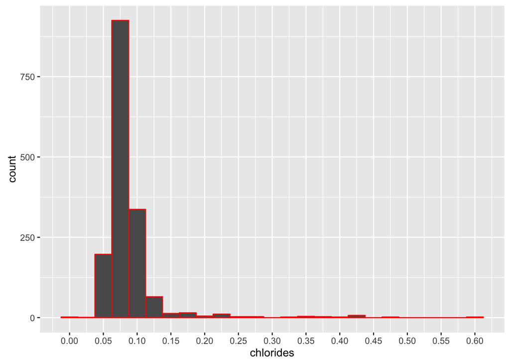

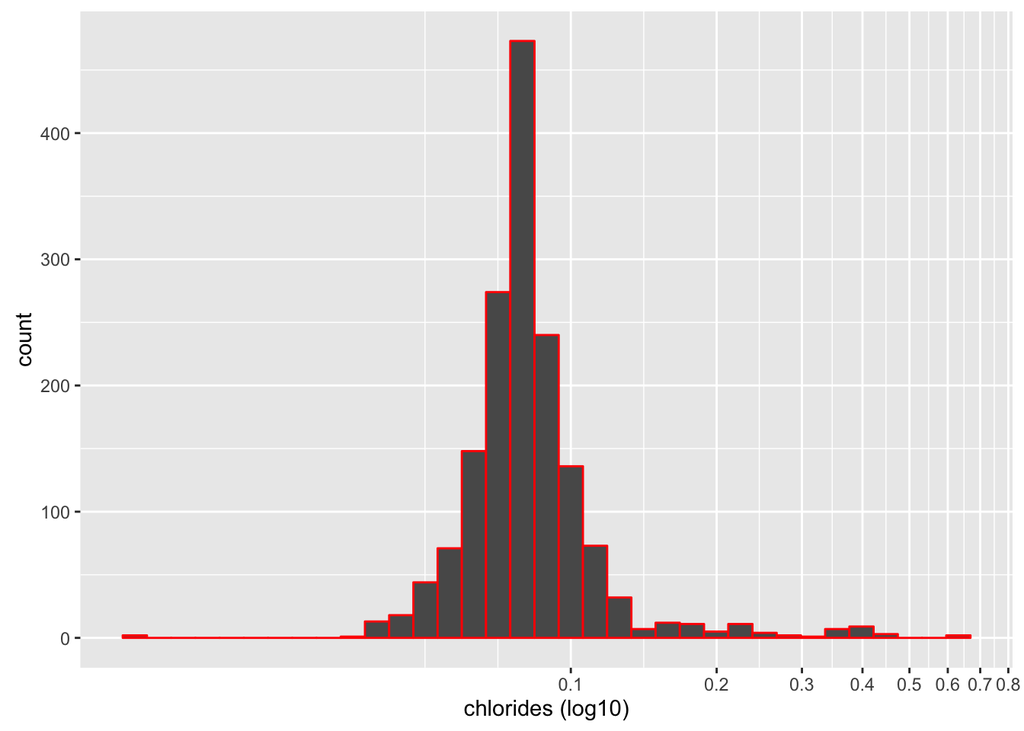

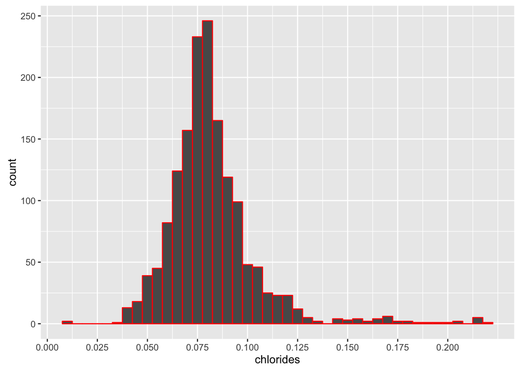

```
## [1] 0.079
```

There are several major outliers for chloride measurment, but around the mean and median the distribution is normal.

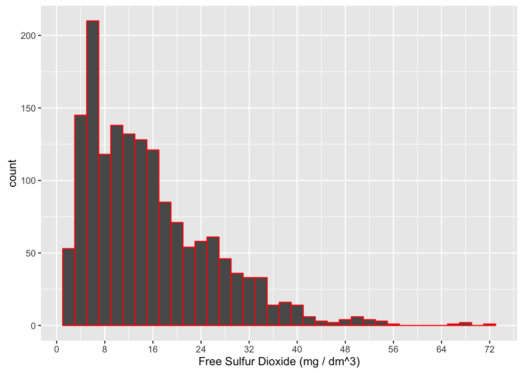

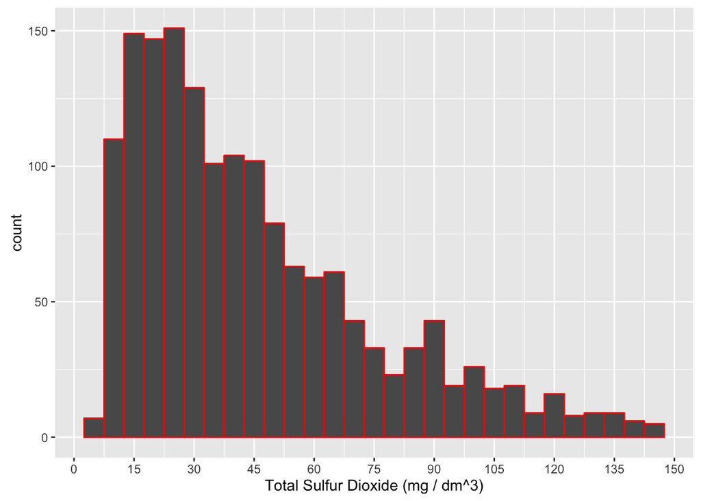

Both measueres of sulfur dioxide are positively skewed. This makes sense because according to the description of the data “SO2 concentrations over 50 ppm [are] evident in the nose and taste of wine.”

```r
# Number of entries with sulfur ppm above 50.
dim(subset(rw, total.sulfur.dioxide >= 50))[1]
```

```
## [1] 557
```

```r
557 / 1599
```

```
## [1] 0.3483427
```

Out of the 1599 entries there are 557 with SO2 above 50. This is about 34.8% of the entries.

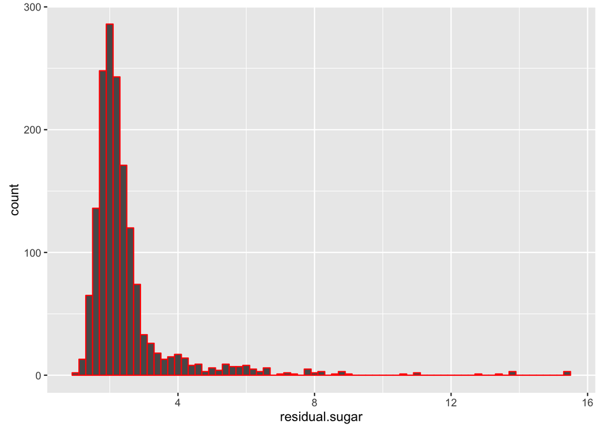

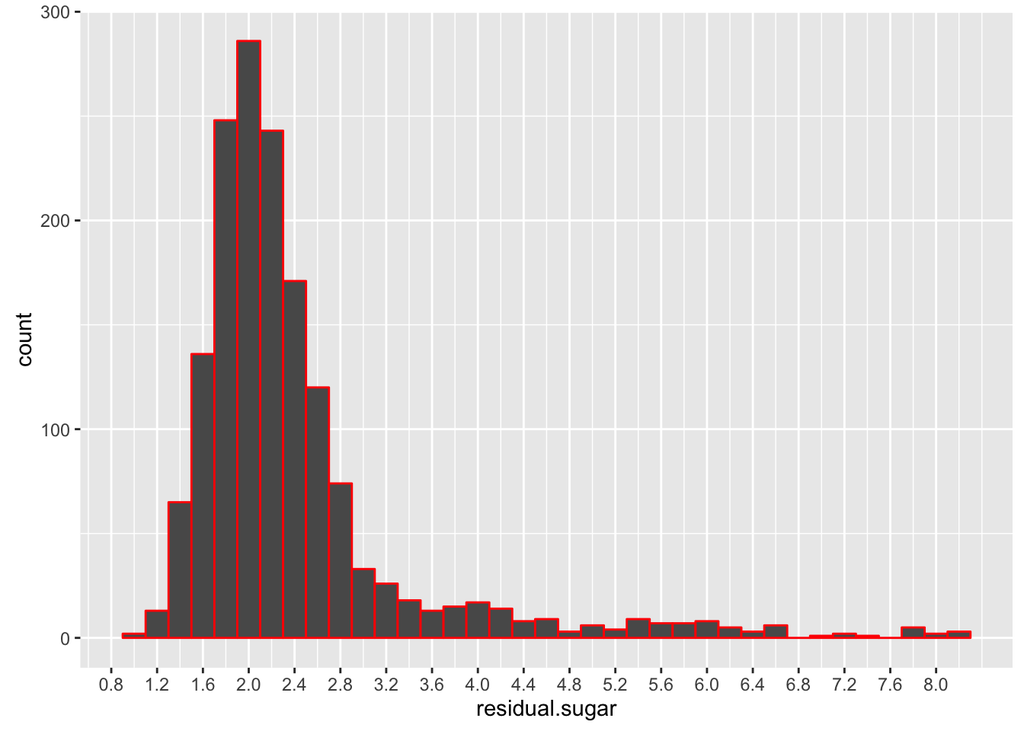

```
##    Min. 1st Qu.  Median    Mean 3rd Qu.    Max.
##   0.900   1.900   2.200   2.539   2.600  15.500
```

Residual sugars are normal with outliers.  
This seems to be a reoccurring pattern. Later it may be interesting to compare the tails with each other to see if there is a correlation between the extremes and good or bad wine.

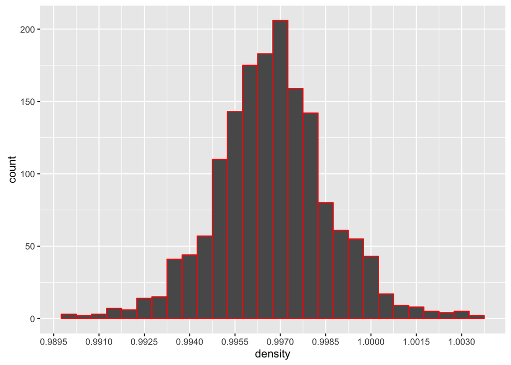

Density is tightly distributed with a normal distribution showing no apparent skewness.

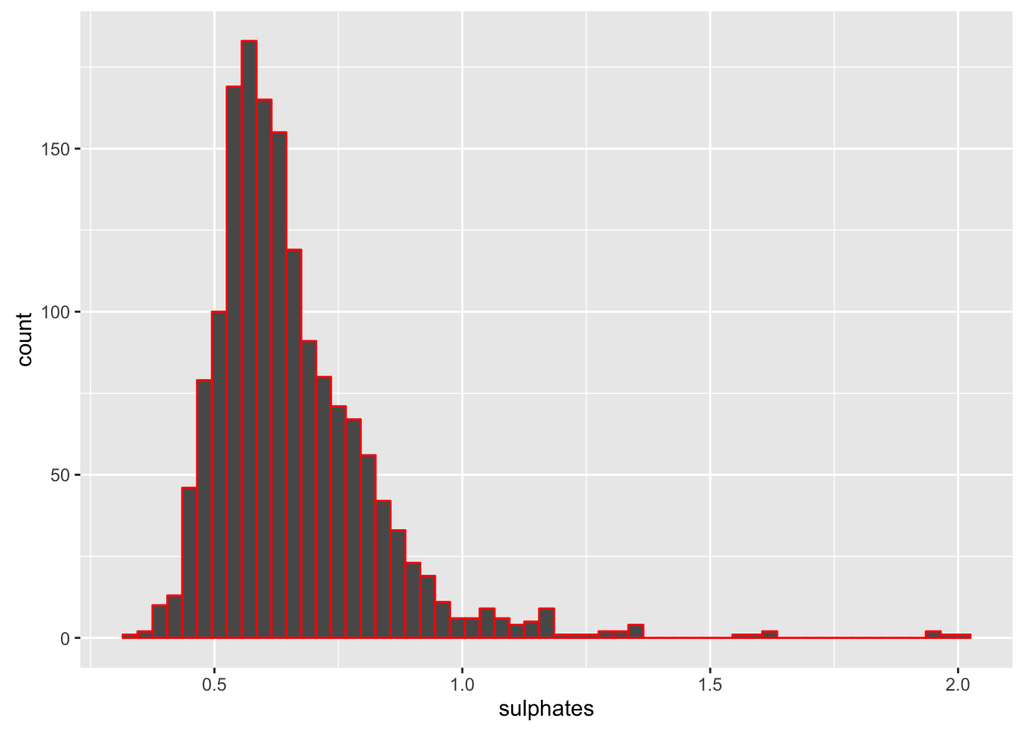

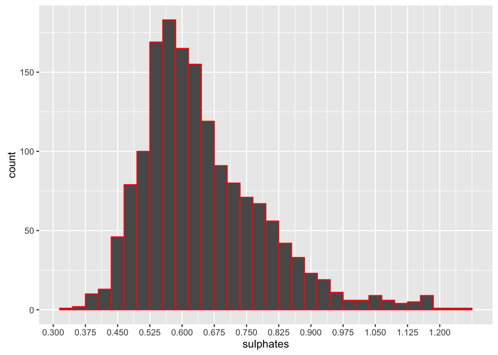

```
##    Min. 1st Qu.  Median    Mean 3rd Qu.    Max.
##  0.3300  0.5500  0.6200  0.6581  0.7300  2.0000
```

Positively skewed with extreme positive outliers. Also, the entries are fairly spread out. According to the data file sulphates “can contribute to sulfur dioxide gas”.

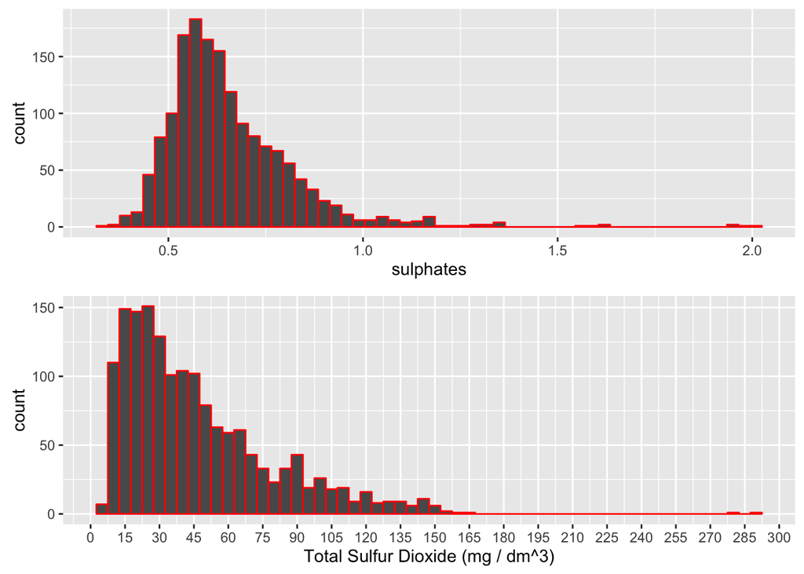

Both do have similar tails, but the total sulfur dioxide is not as normal as the sulphates